# Jak poruszamy się po ReGeneracji?

Naszym celem podczas drugiej fazy projektu było stworzenie aplikacji, która pozwoli na wizualizację tego, jak poruszają się użytkownicy wystawy ReGeneracja w Centrum Nauki Kopernik. Chcieliśmy aby ruch użytkowników był przedstawiony na mapie, oraz żeby użytkownik aplikacji miał możliwość wyboru zakresu czasu, z jakiego chce widzieć dane.

Pierwszym krokiem było wyciągnięcie z danych stworzonych w poprzedniej fazie informacji o tym, jak poruszali się poszczególni użytkownicy. Dla przypomnienia, w poprzedniej fazie dane z każdej stacji zapisaliśmy w oddzielnej tabeli (przy czym każdy miesiąc miał swoją oddzielną tabelę) o następującej formie:

```
##     X month day begin_time visitor_id session_id is_active index end_time
## 1  87   Jan   2   09:34:58    1615300    8233677      TRUE    87 09:36:18
## 2  97   Jan   2   09:44:41    1615299    8233690      TRUE    97 09:45:04
## 3 105   Jan   2   10:06:59    1615313    8233728      TRUE   105 10:09:01
## 4 116   Jan   2   10:17:49    1615330    8233767      TRUE   116 10:17:51
```

Aby uzyskać z tego informację o ścieżkach, należało wczytać po kolei dane ze wszystkich stacji dla kolejnych miesięcy. Dla ustalonego miesiąca przechodzimy po dniach i dla każdego dnia łączymy dane z każdej stacji do jednej ramki, a następnie sortujemy ją po `visitor_id` oraz po `begin_time`. W rezultacie dostajemy ramki danych zawierające wizyty w poszczególnych dniach roku. Realizuje to następujaca funkcja:

```r
get_path_data <- function(path_in, path_out) {
  library(doParallel)
  cl <- makeCluster(4)
  registerDoParallel(cl)
  sciezka <- path_in
  pliki <- list.files(file.path(sciezka))

  foreach(i=formatC(1:12, width = 2, flag= "0")) %dopar% {
  #for(i in formatC(1:12, width = 2, flag= "0")){
    library(stringi)
    library(dplyr)
    pliki_mies <- pliki[stri_detect_fixed(pliki, paste0(i, ".txt"))]
    dane_mies <- vector("list", length(pliki_mies))
    for(l in 1:length(pliki_mies)){
      dane_mies[[l]] <- read.csv(file.path(sciezka, pliki_mies[l]))
    }
    for(j in 1:31){
      dane <- NULL
      # dla każdego miesiąca wczytujemy wszystkie ramki, filtrujemy szukany dzien,
      # i laczymy ze sobą z informacja o tym, z ktorej stacji pochodzi dany wiersz
      for(l in 1:length(pliki_mies)){
        tmp <- dane_mies[[l]]
        tmp %>% filter(day == j) -> tmp
        if(nrow(tmp)>0) {
          tmp$stacja <- stri_sub(pliki_mies[l], from = 11, to = -5)
        }
        dane <- rbind(dane, tmp)
      }
      # wybieramy unikalne id z tego dnia
      unique_id <- unique(dane$visitor_id)

      # szukamy sciezek - szukamy kazdego z unikalnych id,
      # wyniki sortujemy po czasie rozpoczecia, i wybieramy tylko niektore kolumny,
      # zeby mniej miejsca zajmowalo
      #
      if(nrow(dane)>0){
        sciezki <- dane %>% arrange(visitor_id, as.character(begin_time)) %>%
          select(month, day, begin_time, end_time, visitor_id, stacja)
        day <- formatC(j, width = 2, flag= "0")
        names(sciezki)[6] <- "exhibit"
        sciezki$exhibit <- stri_sub(sciezki$exhibit, from = 1, to = -4)
        write.csv(sciezki, file= file.path(path_out,paste0(day, "_", i, ".txt")))
      }
    }
  }
  stopCluster(cl)

  filenames <- list.files(path_out)
  info = file.info(filenames)
  file.remove(filenames[info$size == 3])
}
```

Przykładowe dane z takiej ramki (tutaj dla dnia 1 stycznia):

```
##     X month day begin_time end_time visitor_id exhibit
## 1   1   Jan   1   17:22:21 17:22:21    1615268     63a
## 2   2   Jan   1   17:23:04 17:23:26    1615268     63a
## 3   3   Jan   1   17:23:28 17:35:12    1615268     63a
## 4   4   Jan   1   17:35:28 17:36:52    1615268      18
## 5   5   Jan   1   17:37:09 17:39:02    1615268      20
## 6   6   Jan   1   17:39:05 17:40:46    1615268      12
## 7   7   Jan   1   17:40:49 17:41:58    1615268      21
## 8   8   Jan   1   17:42:07 17:42:35    1615268      66
## 9   9   Jan   1   17:42:44 17:43:55    1615268      16
## 10 10   Jan   1   17:43:58 17:44:41    1615268      16
## 11 11   Jan   1   17:44:46 17:46:14    1615268      11
## 12 12   Jan   1   17:46:21 17:48:18    1615268      09
## 13 13   Jan   1   17:48:23 17:50:11    1615268      17
## 14 14   Jan   1   17:50:22 17:51:41    1615268      13
## 15 15   Jan   1   17:55:31 18:00:12    1615268      10
## 16 16   Jan   1   18:00:13 18:01:47    1615268      05
## 17 17   Jan   1   18:01:51 18:04:31    1615268      67
## 18 18   Jan   1   18:05:48 18:10:30    1615268      06
## 19 19   Jan   1   18:11:02 18:11:23    1615268     78a
## 20 20   Jan   1   18:11:32 18:12:33    1615268      23
## 21 21   Jan   1   18:18:25 18:21:16    1615268      26
## 22 22   Jan   1   18:21:26 18:21:34    1615268      22
## 23 23   Jan   1   18:21:58 18:29:33    1615269      25
```

Następnie ścieżki są zliczane dla każdego dnia, z podziałem na godziny przy użyciu następujących funkcji:

### create_dataFiles

```r
#' Funkcja przetwarza pliki z informacjami o zalogowaniach danego dnia na ramki danych ze
#' zliczonymi sciezkami i wynikowe pliki zapisuje w podanym folderze
#'
#' @param rawDataFolder sciezka dostepu do folderu zawierajacego pliki do obrobki
#' @param returnFolder sciezka dostepu do folderu, w ktorym maja byc zapisane pliki wynikowe
#' @param allExhibits wektor character numerow wszystkich urzadzen
#'
#' @export

create_dataFiles <- function(allExhibits, rawDataFolder, returnFolder){
  filenames <- list.files(rawDataFolder)
  emptyPaths <- create_emptyPaths(allExhibits)

  for(filename in filenames){
    data <- read.table(file.path(rawDataFolder, filename), sep = ",", header = TRUE)[,-1]
    visitors <- unique(data$visitor_id)
    paths <- emptyPaths

    for(visitorId in visitors){
      newPath <- visitor_path(data, visitorId)
      paths <- add_path(newPath, paths)
    }

    write.csv(paths, file = file.path(returnFolder, filename))
  }
}
```

### visitor_path

```r
#' Funkcja wybiera sciezki dla zwiedzajacego (usuwam powroty do tego samego eksponatu) i
#' zwraca ramke danych z informacjami o przejsciach miedzy eksponatami z ich godzina
#'
#' @param data ramka danych z informacjami o wszystkich zalogowaniach do eksponatow
#' danego dnia
#' @param visitorId identyfikator odwiedzajacego
#'
#' @export

visitor_path <- function(data, visitorId){
  tmp <- data[data$visitor_id == visitorId,]
  from <- c("---", as.character(tmp$exhibit))
  to <- c(as.character(tmp$exhibit), "---")
  hour <- c(stri_sub(tmp$begin_time[1], from = 1, to = 2), stri_sub(tmp$end_time, from = 1, to = 2))
  new_path <- data.frame(from = from, to = to, hour = hour)[from != to,]
  new_path
}
```

### add_path

```r
#' Funkcja zwraca zbiorcza ramke danych ~paths uaktualniona o sciezke z ~newPath
#'
#' @param newPath ramka danych z kolumnami $from, $to, $hour opisujaca poruszanie sie
#' konkretnego zwiedzajacego po galerii
#' @param paths ramka danych z informacjami o wszystkich przejsciach w galerii
#'
#' @export

add_path <- function(newPath, paths){
  for(j in 1:nrow(newPath)){
    from = as.character(newPath[j, "from"])
    to = as.character(newPath[j, "to"])
    hour = as.character(newPath[j, "hour"])
    path_row <- which(paths$from == from & paths$to == to)
    if(hour %in% as.character(8:18)){
      paths[path_row, hour] <- paths[path_row, hour] + 1
    }else{
      paths[path_row, "after 19"] <- paths[path_row, "after 19"] + 1
    }
  }
  paths
}
```

### create_emptyPaths

```r
#' Funkcja tworzy ramke danych ze wszystkimi mozliwymi przejsciami miedzy eksponatami
#'
#' @param allExhibits wektor character numerow eksponatow
#'
#' @export

create_emptyPaths <- function(allExhibits){
  emptyPaths <- data.frame(from = "---", to = "---")
  for(i in 1:length(allExhibits)){
    paths <- data.frame(from = c("---", rep(allExhibits[i], length(allExhibits))), to = c(allExhibits[i], allExhibits[-i], "---"))
    emptyPaths <- rbind(emptyPaths, paths)
  }
  emptyPaths <- emptyPaths[-1,]
  hours <- c(8:18, "after 19")
  emptyPaths[,hours] <- 0
  emptyPaths
}
```

Oto struktura wynikowej ramki danych. Kombinacja (`from` == “—”, `to` == “02a”) mówi nam, że stacja o numerze 02a była pierwsza w ścieżce. Analogicznie, wartość `to` równa “—” oznacza koniec ścieżki.

```r
sciezka3 <- paste0(sciezka2, "2")
przykl3 <- read.csv(file.path(sciezka3, "01_01.txt"), head = T)
head(przykl3,4)
```

```
##   X from  to X8 X9 X10 X11 X12 X13 X14 X15 X16 X17 X18 after.19
## 1 2  --- 02a  0  0   0   0   0   0   0   0   0   0   0        0
## 2 3  02a 02b  0  0   0   0   0   0   0   0   0   0   0        0
## 3 4  02a  03  0  0   0   0   0   0   0   0   0   0   0        0
## 4 5  02a  05  0  0   0   0   0   0   0   0   0   0   0        0
```

Kolejnym krokiem było napisanie funkcji służących do rysowania mapy. Ze strony CNK z opisem wystawy ReGeneracja ściągnęliśmy [mapkę](http://www.kopernik.org.pl/odwiedz-nas/plan-centrum/regeneracja/), której, po obróbce graficznej, użyliśmy jako tła wykresu przedstawiającego ścieżki między urządzeniami.

Najpierw stworzyliśmy jako ramkę danych słownik urządzeń (*slownik_urz.csv*) , zawierający numer urządzenia, jego opis, kategorię i współrzędne wyznaczone na podstawie stworzonej mapy.

Przykładowe wiersze z tej ramki to:

```r
slownik_urz <- read.csv(file.path(sciezka, "Mapka","slownik_urz.csv"), stringsAsFactors = F)
head(slownik_urz,4)
```

```
##    nr                nazwa kategoria   x   y
## 1 02a Mózg podczas pracy 1        JA 147 147
## 2 02b Mózg podczas pracy 2        JA 147 201
## 3  03      Pamięć zmysłów         JA 201  60
## 4  05      Strojenie mózgu        JA 201 132
```

Następnie przygotowaliśmy sobie funkcje nanoszące kolejne elementy na mapę. Aby pokazać ich działanie, wygenerujmy przykładowe dane:

```r
# przykladowa liczba przejsc miedzy jednym a drugim urzadzeniem
wartosci <- round(abs(rnorm(nrow(slownik_urz), 0, 100)))
# przykladowe polaczenia
dane <- data.frame( from= slownik_urz$nr, to = slownik_urz[order(slownik_urz$nazwa, decreasing = T),"nr"],
                    total= wartosci, stringsAsFactors = F)[1:10,]

# wybieram format danych odpowiedni dla funkcji zwiazanych z polaczeniami
rownames(slownik_urz) <- slownik_urz$nr
pocz <- slownik_urz[dane$from, ]
kon <- slownik_urz[dane$to, ]

# wybieram format danych odpowiedni dla funkcji zwiazanych z urzadzeniami
lacznie <- rbind(pocz,kon)
lacznie <- lacznie[!duplicated(lacznie),]
lacznie <- cbind(lacznie, nr = rownames(lacznie))
```

Poniżej przedstawiamy skonstruowane funkcje, wraz z ich opisem z dokumentacji i przykładowym wywołaniem.

### plot_map

Funkcja wyrysowująca przerobioną wcześniej mapkę jako tło wykresu.

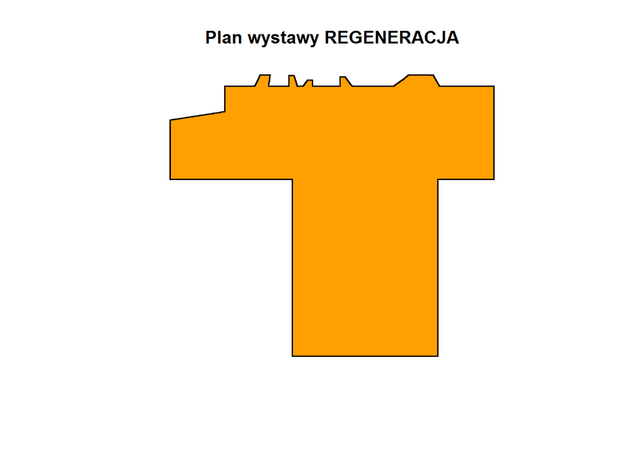

```r
#' Funkcja służy do rysowania planu wystawy Regeneracja
#'
#' @param sciezka ścieżka dostępu do pliku .png z planem wystawy
#' @param obram  czy narysować prostokąt wokół planu (domyślnie FALSE)
#' @param tytul tytuł mapy (domyślnie "Plan wystawy REGENERACJA")
#'
#' @return zwraca 2 - elem. wektor liczbowy z rozmiarami obrazu, którego użyliśmy
#'
#' @export

plot_mapa <- function(sciezka, obram = FALSE, tytul = "Plan wystawy REGENERACJA" )
{
   require('png')
   png <- readPNG(sciezka, native=T)
   res <-  c(dim(png)[2] , dim(png)[1])
   plot(1, 1, xlim =c( 0, res[1] ), ylim=c(0,res[2]),asp=1,type='n',xaxs='i',yaxs='i',xaxt='n',yaxt='n',xlab='',ylab='',bty='n', main=tytul)
   rasterImage(png,0,0,res[1],res[2] )

   if (obram){
      rect(0,0,res[1],res[2])
   }
   return(res)
}
rozmiary <- plot_mapa(file.path(sciezka,"Mapka","MAPKA_KRAW1.png"), obram=F)
```

### plot_urzadz

Funkcja dodająca znaczniki urządzeń (najpierw wywołujemy plot_map).

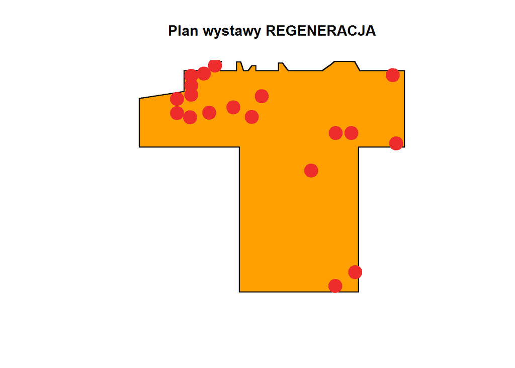

```r
#' Funkcja służy do nanoszenia na mapę punktów odpowiadających urządzeniom
#'
#' Funkcja wymaga uprzedniego wywołania plot.new (np. przez wywołanie funkcji plot_mapa)
#'
#' @param dane_urz ramka danych z kolumnami x i y odpowiadającymi współrzędnym urządzeń
#' @param pch rodzaj znacznika urządzeń
#' @param rozmiary rozmiary planu, na który nanosimy punkty
#' @param col kolor znacznika
#' @param cex wielkość znacznika
#'
#' @export
plot_urzadz <- function(dane_urz,  pch=19, cex=2.5, col="firebrick2", rozmiary = c(1018, 886)){

   points( x= dane_urz$x, y= rozmiary[2] - dane_urz$y, pch=pch, cex=cex, col = col )

}
rozmiary <- plot_mapa(file.path(sciezka,"Mapka","MAPKA_KRAW1.png"), obram=F)
plot_urzadz(lacznie, pch=19, cex=2.5, col="firebrick2", rozmiary = c(1018, 886))
```

### plot_etykiety_nr

Funkcja dodająca etykiety z numerami urządzeń (najpierw plot_map).

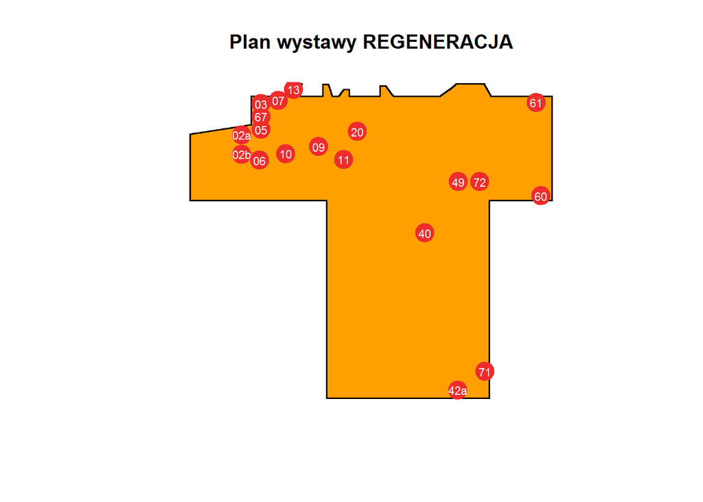

```r
#' Funkcja służy do rysowania etykiet z numerami urządzeń
#'
#' Funkcja wymaga uprzedniego wywołania plot.new (np. przez wywołanie funkcji plot_mapa)
#'
#' @param dane_urz ramka danych z kolumnami x i y odpowiadającymi współrzędnym urządzeń oraz kolumną nr - numerem urządzenia
#' @param przes 2 - el. wektor przesunięcia etykiet, dodatnie wartości oznaczają odpowiednio: w lewo, w dół, ujemne prawo, góra
#' domyślnie etykiety są ustawione na środku linii łączącej punkty
#' @param rozmiary rozmiary planu, na który nanosimy punkty
#' @param col kolor tekstu etykiet
#' @param cex wielkość tekstu etykiet
#'
#' @export

plot_etykiety_nr <- function(dane_urz, przes= c(0,0), cex=0.7, col="white", rozmiary = c(1018, 886)){

   text( x = dane_urz$x - przes[1], y= rozmiary[2] - dane_urz$y - przes[2], labels = dane_urz$nr,  cex=cex, col = col )

}
rozmiary <- plot_mapa(file.path(sciezka,"Mapka","MAPKA_KRAW1.png"), obram=F)
plot_urzadz(lacznie, pch=19, cex=2.5, col="firebrick2", rozmiary = c(1018, 886))
plot_etykiety_nr(lacznie, cex=0.7, col="white", rozmiary = c(1018, 886))
```

### plot_etykiety

Funkcja dodająca etykiety z opisami urządzeń (pierw plot_map).

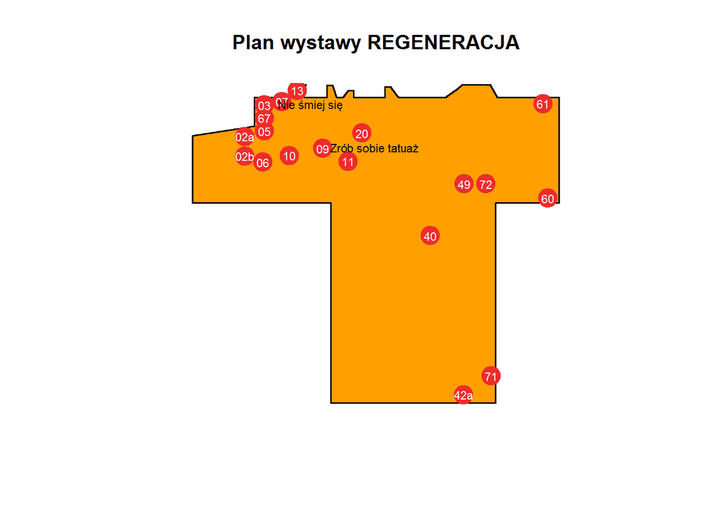

```r
#' Funkcja służy do rysowania etykiet z pełnymi nazwami urządzeń
#'
#' Funkcja wymaga uprzedniego wywołania plot.new (np. przez wywołanie funkcji plot_mapa)
#'
#' @param dane_urz ramka danych z kolumnami x i y odpowiadającymi współrzędnym urządzeń oraz kolumną nazwa - opisem urządzenia
#' @param przes 2 - el. wektor przesunięcia etykiet, dodatnie wartości oznaczają odpowiednio: w lewo, w dół, ujemne prawo, góra
#' domyślnie etykiety są ustawione na środku linii łączącej punkty
#' @param rozmiary rozmiary planu, na który nanosimy punkty
#' @param col kolor tekstu etykiet
#' @param cex wielkość tekstu etykiet
#'
#' @export
plot_etykiety <- function(dane_urz, cex=0.7, col="black", rozmiary = c(1018, 886), przes = c(-40,40)){

   text( x = dane_urz$x - przes[1], y= rozmiary[2] - dane_urz$y - przes[2], labels = dane_urz$nazwa,  cex=cex, col = col )

}

rozmiary <- plot_mapa(file.path(sciezka,"Mapka","MAPKA_KRAW1.png"), obram=F)
plot_urzadz(lacznie, pch=19, cex=2.5, col="firebrick2", rozmiary = c(1018, 886))
plot_etykiety_nr(lacznie, cex=0.7, col="white", rozmiary = c(1018, 886))
plot_etykiety(lacznie[c(10,12),], cex=0.7, col="black", rozmiary = c(1018, 886), przes = c(-40,40))
```

### plot_polaczenia

Funkcja dodająca połączenia (najpierw plot_map).

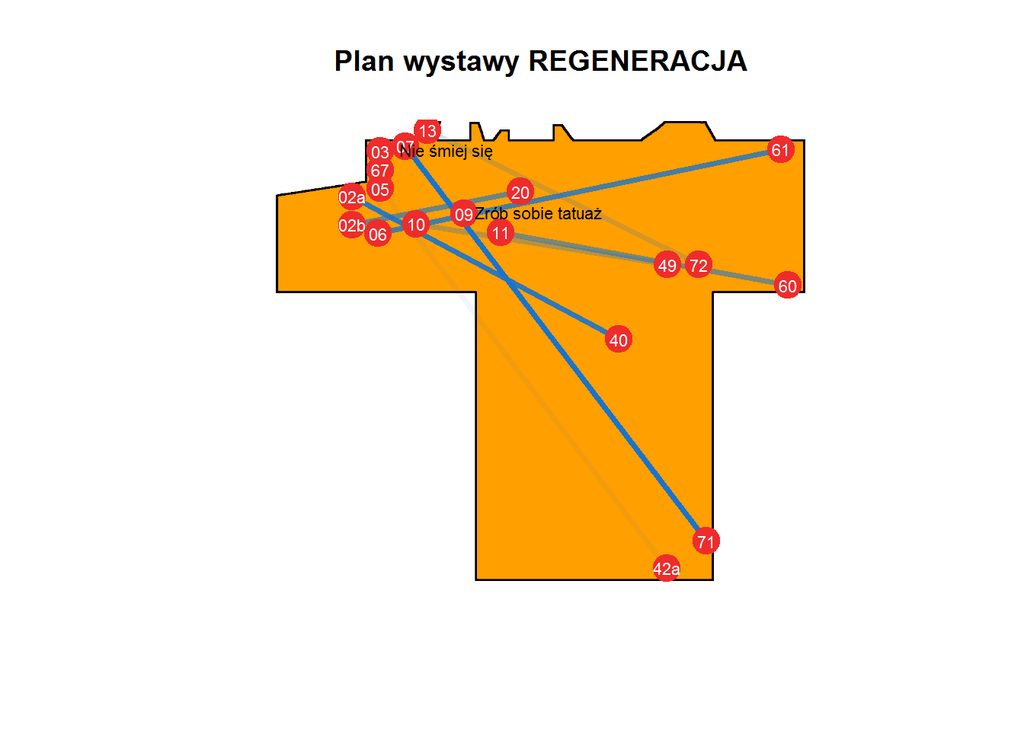

```r
#' Funkcja służy do rysowania połączeń między punktami
#'
#' Funkcja wymaga uprzedniego wywołania plot.new (np. przez wywołanie funkcji plot_mapa)
#'
#' @param dane_pocz ramka danych z kolumnami x i y odpowiadającymi współrzędnym początkowych urządzeń
#' @param dane_kon ramka danych z kolumnami x i y odpowiadającymi współrzędnym końcowych urządzeń
#' @param wartosci wektor o długości równej długości powyższych ramek danych z liczbami połączeń
#' @param rozmiary rozmiary planu, na który nanosimy punkty
#' @param col kolor linii
#' @param lwd grubość linii
#'
#' @export



plot_polaczenia <- function(dane_pocz, dane_kon, wartosci, col="dodgerblue3",lwd = 3.5 ,rozmiary = c(1018, 886)){

   doRGB <- as.numeric(col2rgb(col))/255
   alfy <- wartosci/max(wartosci)
   segments(x0= dane_pocz$x, y0= rozmiary[2] - dane_pocz$y, x1= dane_kon$x, y1= rozmiary[2] - dane_kon$y,
            lwd=lwd, col = rgb(doRGB[1],doRGB[2],doRGB[3],alpha=alfy))

}
rozmiary <- plot_mapa(file.path(sciezka,"Mapka","MAPKA_KRAW1.png"), obram=F)
plot_polaczenia(pocz, kon, dane$total, col="dodgerblue3",lwd = 3.5 ,rozmiary = c(1018, 886))
plot_urzadz(lacznie, pch=19, cex=2.5, col="firebrick2", rozmiary = c(1018, 886))
plot_etykiety_nr(lacznie, cex=0.7, col="white", rozmiary = c(1018, 886))
plot_etykiety(lacznie[c(10,12),], cex=0.7, col="black", rozmiary = c(1018, 886), przes = c(-40,40))
```

### plot_liczby

Funkcja dodająca etykiety nad liniami (pierw plot_map).

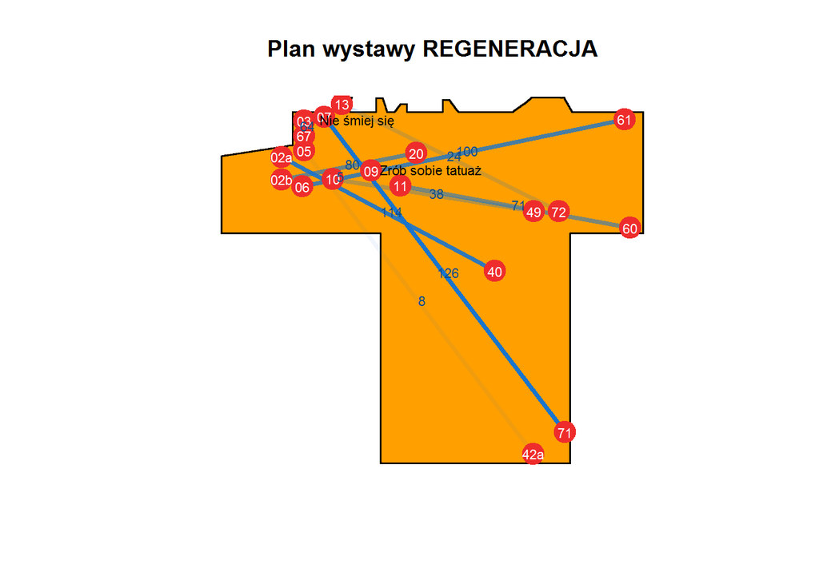

```r
#' Funkcja służy do rysowania etykiet z liczbami nad liniami łączącymi urządzenia
#'
#' Funkcja wymaga uprzedniego wywołania plot.new (np. przez wywołanie funkcji plot_mapa)
#'
#' @param dane_pocz ramka danych z kolumnami x i y odpowiadającymi współrzędnym początkowych urządzeń
#' @param dane_kon ramka danych z kolumnami x i y odpowiadającymi współrzędnym końcowych urządzeń
#' @param wartosci wektor o długości równej długości powyższych ramek danych z etykietami wyświetlanymi nad liniami
#' @param przes 2 - el. wektor przesunięcia etykiet, dodatnie wartości oznaczają odpowiednio: w lewo, w dół, ujemne prawo, góra
#' domyślnie etykiety są ustawione na środku linii łączącej punkty
#' @param rozmiary rozmiary planu, na który nanosimy punkty
#' @param col kolor tekstu etykiet
#' @param cex wielkość tekstu etykiet
#'
#' @export

plot_liczby <- function(dane_pocz, dane_kon, wartosci, przes=c(-2,-5), cex=0.9, col="dodgerblue4", rozmiary = c(1018, 886)){

   diff_x <- (dane_kon$x + dane_pocz$x)/2
   diff_y <- (dane_kon$y + dane_pocz$y)/2
   text( x = diff_x - przes[1], y= rozmiary[2] - diff_y - przes[2], labels = wartosci,  cex=cex, col = col )

}


rozmiary <- plot_mapa(file.path(sciezka,"Mapka","MAPKA_KRAW1.png"), obram=F)
plot_polaczenia(pocz, kon, dane$total, col="dodgerblue3",lwd = 3.5 ,rozmiary = c(1018, 886))
plot_urzadz(lacznie, pch=19, cex=2.5, col="firebrick2", rozmiary = c(1018, 886))
plot_etykiety_nr(lacznie, cex=0.7, col="white", rozmiary = c(1018, 886))
plot_etykiety(lacznie[c(10,12),], cex=0.7, col="black", rozmiary = c(1018, 886), przes = c(-40,40))
plot_liczby(pocz, kon, wartosci = dane$total, rozmiary=rozmiary, przes=c(-8,-5), cex=0.7, col="dodgerblue4")
```

### Przykładowe wywołanie z innym tłem.

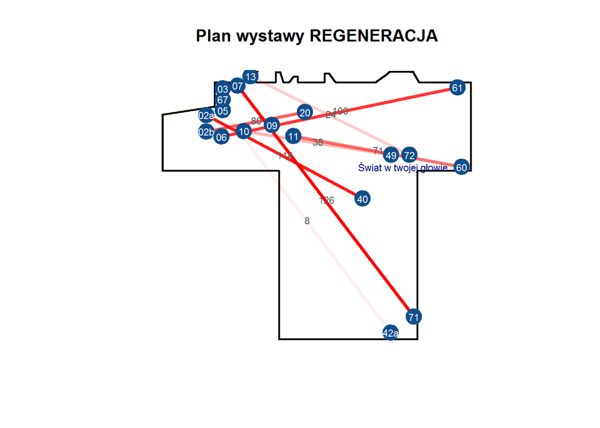

```r
rozmiary <- plot_mapa(file.path(sciezka,"Mapka","MAPKA_KRAW.png"), obram=F)
plot_polaczenia(pocz, kon, dane$total, col="red",lwd = 3.5 ,rozmiary = c(1018, 886))
plot_liczby(pocz, kon, wartosci = dane$total, rozmiary=rozmiary, przes=c(-2,-5), cex=0.7, col="grey36")
plot_urzadz(lacznie, pch=19, cex=2.5, col="dodgerblue4", rozmiary = c(1018, 886))
plot_etykiety_nr(lacznie, cex=0.7, col="white", rozmiary = c(1018, 886))
plot_etykiety(lacznie[c(14,17),], cex=0.7, col="navyblue", rozmiary = c(1018, 886), przes = c(-40,40))
```

### plot_paths

Funkcja pozwalająca wywołać funkcję rysującą połączenia na konkretnym zbiorze danych (zbiór danych ma konkretną strukturę, która uwzględniamy w tej postaci funkcji)

```r
#' Funkcja służy do rysowania scieżek z danych
#'
#' @param data ramka danych z kolumnami tekstowymi from i to określającymi urządzenia początkowe i końcowe oraz numeryczną
#' kolumną total
#' @param slownik ramka danych z kolumnami x i y określającymi współrzedne urządzeń i kolumną nr określającą numer urządzenia
#'
#' @export


plot_paths <- function(data, slownik){
   rownames(slownik) <- slownik$nr
   data %>% filter(from != "---" & to != "---") -> data
   pocz <- slownik[data$from, 4:5]
   kon <- slownik[data$to, 4:5]
   print(head(pocz))
   plot_polaczenia(pocz, kon, wartosci = data$total)
}
```

### plot_polaczenia_graph

Funkcja rysująca połączenia przy użyciu krzywych zakończonych strzałkami.

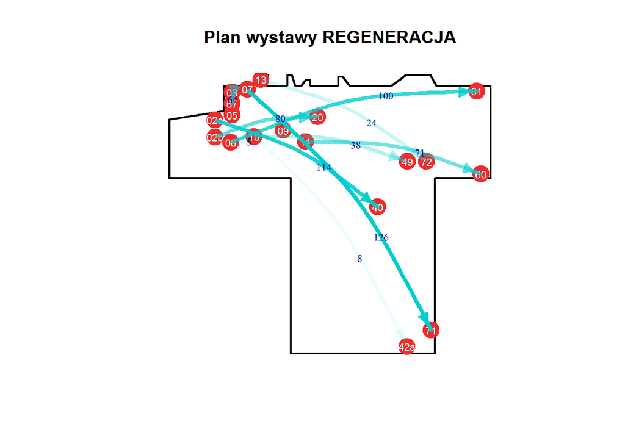

```r
#' Funkcja służy do rysowania połączeń między danymi za pomocą dostosowanych strzałek
#'
#' @param data ramka danych o trzech kolumnach (from, to i total)
#' @param rozmiary = rozmiary mapy, na której rsyujemy
#' @param alpha = wartosci, które posłużą do dobru przeźroczystości połączeń
#' @param slownik słownik ze współrzędnymi urządzeń i ich nazwami
#' @param czyStrzalki czy rysować kierunek połączenia
#' @param kolLinii kolor linii
#' @param szerLinii szerokość linii
#' @param krzywLinii krzywizna linii [0,1]
#' @param rozmiarStrzalek rozmiar strzałek
#' @param szerStrzalek szerokość strzałek
#' @param typLinii typ linii (0 or “blank”, 1 or “solid”, 2 or “dashed”, 3 or “dotted”, 4 or “dotdash”, 5 or “longdash”,
#' 6 or “twodash”
#' @param etykLinii etykiety rysowane nad linią
#' @param etykLiniiRozmiar rozmiar tych etykiet
#'
#' @export

plot_polaczenia_graph <- function(data, rozmiary = c(1018, 886), alpha, slownik, czyStrzalki = F,
                            kolLinii = "cyan3",
                            szerLinii = 4,
                            krzywLinii = 0.2,
                            rozmiarStrzalek = 0.5,
                            szerStrzalek = 1,
                            typLinii = "solid",
                            etykLinii = "",
                            etykLiniiRozmiar = 1){
   require(igraph)

   # dbam o to, by mieć charactery zamiast factorów
   data[,"from"] <- as.character(data[,"from"])
   data[,"to"] <- as.character(data[,"to"])

   #wybieram wspolrzedne tylko tych urzadzen ze slownika, ktore sa w danych
   meta <- slownik[slownik$nr %in% c(data$from, data$to),c("nr","x", "y")]

   #poprawiam współrzędne y-owe (współrzędne wzięte z programu graficznego zaczynają się w górnym, lewym rogu)
   meta$y <- rozmiary[2] - meta$y

   meta$nr <- as.character(meta$nr)

   #tworzę strukturę grafu
   g <- graph.data.frame(data, directed=czyStrzalki, vertices=meta)

   #definiuję jak mają rysowane być linie
   alpha <-(alpha/max(alpha))
   doRGB <- as.numeric(col2rgb(kolLinii))/255
   E(g)$color <- rgb(doRGB[1],doRGB[2],doRGB[3],alpha=alpha)
   E(g)$width <- szerLinii

   # rysuję graf, nakładając go na już istniejącą mapę
   lo <- as.matrix(meta[,c("x","y")])
   plot(g, layout = lo, rescale=F, add=T,
        edge.curved=krzywLinii,
        edge.arrow.size = rozmiarStrzalek,
        edge.arrow.width = szerStrzalek,
        edge.lty = typLinii,
        edge.label= etykLinii,
        edge.label.cex = etykLiniiRozmiar,
        vertex.shape="none",
        vertex.label = "")
}


rozmiary <- plot_mapa(file.path(sciezka,"Mapka","MAPKA_KRAW.png"), obram=F)
plot_urzadz(lacznie, pch=19, cex=2.5, col="firebrick2", rozmiary = c(1018, 886))
plot_etykiety_nr(lacznie, cex=0.7, col="white", rozmiary = c(1018, 886))
plot_polaczenia_graph(dane, alpha= dane$total, slownik = slownik_urz, czyStrzalki = T,
                      etykLinii = dane$total, rozmiarStrzalek = 1, etykLiniiRozmiar = 0.7)
```

### plot_paths_graph

Funkcja analogiczna do plot_paths, ale z użyciem plot_polaczenia_graph

```r
#' Funkcja służy do rysowania scieżek z danych
#'
#' @param data ramka danych z kolumnami tekstowymi from i to określającymi urządzenia początkowe i końcowe oraz numeryczną
#' kolumną total
#' @param slownik ramka danych z kolumnami x i y określającymi współrzędne urządzeń i kolumną nr określającą numer urządzenia
#'
#' @export

plot_paths_graph <- function(data, slownik){
   data %>% filter(from != "---" & to != "---") -> data
   plot_polaczenia_graph(data, alpha = data$total, slownik = slownik, etykLinii = data$total)
}
```

Funkcje rysujące wykresy, pliki graficzne oraz dane stworzone w poprzednim kroku zostały umieszczone w pakiecie `sciezkiCNK` dostępnym pod adresem https://github.com/topolskib/sciezkiCNK. Poza wymienionymi wyżej funkcjami do rysowania ścieżek, znalazły się tam również dwie funkcje służące do selekcji danych według tego, jakie ustawienia wybierze użytkownik aplikacji.

### filter_data

```r
#' Funkcja służy do filtrowania danych po miesiącach, dniach tygodnia i godzinach.
#'
#' @param weekdays Wektor zawierający numeryczne wartości dni tygodnia,
#' które chcemy uwzględnić.
#'
#' @param months Wektor zawierający numeryczne wartości miesięcy,
#' które chcemy uwzględnić.
#'
#' @param hours Wektor dwuelementowy zawierający informacje o przedziale godzin, który chcemy uwzględnić
#'
#'
#' @export

filter_data <- function(weekdays = c(1,7), months = c(1,12), hours=c(9,20)) {
  require(dplyr)
  require(stringi)
  daty <- seq.Date(from = as.Date("2013-01-01"), to = as.Date("2013-12-31"), by = 1)
  days <- format(daty[as.numeric(format.Date(daty, format ="%u")) %in% weekdays], format = "%d_%m")
  filtered <- dane_all[days]
  filtered <- filtered[(as.numeric(stri_sub(names(filtered), 4,5)) %in% months)]
  suma <- 0
  print(length((filtered)))
  if(hours[1] == hours[2]) {
    for(i in 1:length(filtered)){
      suma <- suma + filtered[[i]][,(hours[1]-5)]
    }

  }
  else {
    for(i in 1:length(filtered)){
      suma <- suma + rowSums(filtered[[i]][,(hours[1]-5):(hours[2]-5)])
    }
  }
  wynik <- cbind(dane_all[[1]][,2:3],suma)
  names(wynik)[3] <- "total"
  wynik
}
```

### filter_data_byday

```r
#' Funkcja służy do filtrowania danych po miesiącach, dniach tygodnia i godzinach.
#'
#' @param days Wektor zawierający skrajne wartości zakresu dni, które chcemy uwzględnić
#'
#' @param hours Wektor dwuelementowy zawierający informacje o przedziale godzin, który chcemy uwzględnić
#'
#'
#' @export

filter_data_byday <- function(days, hours=c(9,20)){
  dates <- seq.Date(from = as.Date(days[1]), to = as.Date(days[2]), by = 1)
  dates <- format(dates, format = "%d_%m")
  dates <- dates[dates %in% names(dane_all)]
  filtered <- dane_all[dates]
  suma <- 0
  print(length((filtered)))
  if(hours[1] == hours[2]) {
    for(i in 1:length(filtered)){
      suma <- suma + filtered[[i]][,(hours[1]-5)]
    }

  }
  else {
    for(i in 1:length(filtered)){
      suma <- suma + rowSums(filtered[[i]][,(hours[1]-5):(hours[2]-5)])
    }
  }
  wynik <- cbind(dane_all[[1]][,2:3],suma)
  names(wynik)[3] <- "total"
  wynik
}
```

Mając wszystkie potrzebne elementy w jednym pakiecie można było przystąpić do pisania aplikacji. Oto plik `server.R`.

```r
weekdays <- as.list(c(2:7))
names(weekdays) <- c("Wtorek", "Środa", "Czwartek", "Piątek", "Sobota", "Niedziela")

weekdays_choices <- as.list(c(1:4))
names(weekdays_choices) <- c("Cały tydzień", "Wtorek - Piątek", "Sobota - Niedziela", "Custom")

months_choices <- as.list(c(1:3))
names(months_choices) <- c("Cały rok", "Wakacje (Lipiec - Sierpień)", "Custom")

data(dane_all)
data("slownik_urz")
data("mapka_png")
rownames(slownik_urz) <- slownik_urz$nr
slownik_urz %>% filter(x != 0) -> slownik_urz

shinyServer(function(input, output, session) {

  AppType <- reactive({
    input$AppType
  })

  selectedWeekDays <- reactive({
    if(AppType() == 2){
      if(input$dzienTygodnia == 1) {return(2:7)}
      if(input$dzienTygodnia == 2) {return(2:5)}
      if(input$dzienTygodnia == 3) {return(6:7)}
      if(input$dzienTygodnia == 4) {
        return(input$dzienTygodniaCustom)}
    }
    else {return(2:7)}
  })

  selectedMonths <- reactive({
    print("c")
    if(AppType() == 2){
      if(input$miesiac == 1) {return(1:12)}
      if(input$miesiac == 2) {return(7:8)}
      if(input$miesiac == 3) {return(input$miesiacCustom[1]:input$miesiacCustom[2])}
    }
    else {return(1:12)}
  })

  selectedPathLength <- reactive({
    input$czySciezka
  })

  output$SelektorDni <- renderUI({
    if(AppType() == 1){
      dateRangeInput(inputId = "dzien",
                  label = "Wybierz zakres dni",
                  start = "2013-01-01",
                  end = "2013-12-31",
                  min = "2013-01-01",
                  max = "2013-12-31",
                  weekstart = 1,
                  language = "pl",
                  separator = " do ")
    }
  })

  output$SelektorDniaTygodnia <- renderUI({
    if(AppType() == 2){
      selectInput(inputId = "dzienTygodnia",
                  label = "Wybierz zakres dni tygodnia",
                  choices = weekdays_choices,
                  selected = 1)
    }
  })

  output$SelektorDniaTygodniaCustom <- renderUI({
    if(AppType() == 2){
      if(input$dzienTygodnia == 4){
        checkboxGroupInput(inputId = "dzienTygodniaCustom",
                    label = "Wybierz dni tygodnia",
                    choices = weekdays,
                    selected = 2:7)
      }
    }
  })

  output$SelektorMiesiaca <- renderUI({
    if(AppType() == 2){
      selectInput(inputId = "miesiac",
                  label = "Wybierz zakres miesięcy",
                  choices = months_choices,
                  selected = 1)
    }
  })

  output$SelektorMiesiacaCustom <- renderUI({
    if(AppType() == 2){
      if(input$miesiac == 3){
        sliderInput(inputId = "miesiacCustom",
                    label = "Wybierz miesiące",
                    min=1,
                    max = 12,
                    value = c(1,12),
                    step = 1,
                    round = TRUE)
      }
    }
  })


  output$SelektorDlugosciSciezki <- renderUI({
    if(selectedPathLength()) {
      sliderInput(inputId = "dlugoscSciezki",
                  label = "Wybierz długość ścieżki",
                  min = 7,
                  max = 24,
                  value = 10,
                  step = 1,
                  round = TRUE)
    }
  })


  output$text <- renderUI({
    str1 <- findClosest(c(input$plot_hover$x, 886 - input$plot_hover$y), slownik_urz)[1]
    str2 <- findClosest(c(input$plot_hover$x, 886 - input$plot_hover$y), slownik_urz)[2]
    HTML(paste(str1, str2, sep = '<br/>'))

  })

  output$sciezki <- renderPlot({
    # Selekcja danych przed narysowaniem
    daty <- seq.Date(from = as.Date("2013-01-01"), to = as.Date("2013-12-31"), by = 1)
    if(AppType() == 2){
      filtr <- filter_data(weekdays = selectedWeekDays(), months = selectedMonths(), hours = input$godzina)
    }
    if(AppType() == 1){
      if(input$dzien[2]>= input$dzien[1]) {
        filtr <- filter_data_byday(days =input$dzien ,hours = input$godzina)
      }
      else filtr <- filter_data_byday(days = rev(input$dzien), hours = input$godzina)
    }
    filtr$from <- as.character(filtr$from)
    filtr$to <- as.character(filtr$to)
    sciezka <- sciezka(filtr, input$dlugoscSciezki)
    sciezka <- sciezka %>% filter(from %in% slownik_urz$nr, to %in% slownik_urz$nr)
    if(max(filtr$total)!=0){
      filtr$total <- filtr$total / sort(filtr$total, decreasing = T)[8]
    }
    filtr$total[filtr$total>1] <- 1
    filtr$total <- filtr$total^1.3
    print(sort(filtr$total, decreasing = T)[1:10])
    rozmiary <- plot_mapa(mapka_png, obram=F)
    plot_paths(filtr, slownik_urz, col = "#160773")
    if(selectedPathLength()){
      plot_polaczenia_graph(data = sciezka ,
                            slownik = slownik_urz,
                            alpha = 0.5,
                            czyStrzalki = T,
                            szerStrzalek = 2,
                            kolLinii = "#bf1010",
                            rozmiarStrzalek = 1 )
    }
    plot_urzadz(slownik_urz, col = "#3a2e85", cex=3.7)
    plot_etykiety_nr(slownik_urz, przes= c(0,0), cex = 0.9)
  }, height = 900, width = 800)
})
```

A oto plik `ui.R`:

```r
library(shiny)
library(dplyr)
library(stringi)
library(png)
library(sciezkiCNK)
library(igraph)
appTypes <- as.list(1:2)
names(appTypes)<- c("Dni w roku",  "Miesiące, dni tygodnia oraz godziny")

shinyUI(fluidPage(
  titlePanel("Jak poruszamy się po CNK?"),
  sidebarLayout(
    sidebarPanel(
      selectInput(inputId = "AppType",
                  label = "Wybierz jak chcesz agregować ścieżki",
                  choices = appTypes,
                  selected = 1),
      htmlOutput("SelektorDni"),
      htmlOutput("SelektorMiesiaca"),
      htmlOutput("SelektorMiesiacaCustom"),
      htmlOutput("SelektorDniaTygodnia"),
      htmlOutput("SelektorDniaTygodniaCustom"),
      sliderInput(inputId = "godzina",
                  label = "Wybierz zakres godzin",
                  min = 9,
                  max = 20,
                  value = c(9,20),
                  step = 1,
                  round = TRUE),
      checkboxInput(inputId = "czySciezka",
                    label = "Typowa ścieżka",
                    value = TRUE),
      htmlOutput("SelektorDlugosciSciezki"),
      htmlOutput("text")
    ),
    mainPanel(
      plotOutput("sciezki", width = "100%", hover = "plot_hover")
    )
  )
))
```

Gotowa aplikacja dostępna jest pod adresem https://topolskib.shinyapps.io/CNK_sciezki/.